# E013 Pho4 chimera activity analysis, new host

Bin He

2022-03-30 updated 2022-04-05

```r
require(tidyverse)
require(cowplot)
```

# Goal

- Analyze the latest batches of flow cytometry data to determine the contribution of different (matching) parts of ScPho4 and CgPho4 to their difference in Pho2 dependence.
- Develop an analysis pipeline to perform QC, correction (if needed) and plotting the results.

# Data

Merge the three batches

```r
raw <- list(
  "03/15/22" = read_tsv("../data/20220315-EO-chimera-batch-1/20220329-gated-median-out.txt", show_col_types = FALSE),
  "03/22/22" = read_tsv("../data/20220322-EO-chimera-batch-2/20220327-gated-median-out.txt", show_col_types = FALSE),
  "03/29/22" = read_tsv("../data/20220329-EO-chimera-batch-3/20220330-gated-median-out.txt", show_col_types = FALSE)
)
dat <- bind_rows(raw, .id = "date") %>%
  #separate(col = well, sep = 1, into = c("row", "col")) %>%
  separate(col = sample, sep = "-", into = c("plasmid", "host", "rep"))
```

# QC

## 1. Number of events per sample

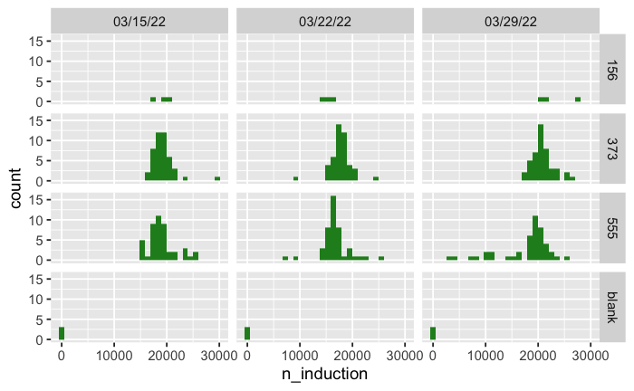

```r
dat %>% ggplot(aes(x = n_induction)) + geom_histogram(bins = 30, fill = "forestgreen") + facet_grid(host~date) + theme_gray(base_size = 14) #+ panel_border()
```

*Discussion*

1. Majority of the experimental wells (not blank) have > 10000 events, with the exception of a few samples

   | date | well | plasmid | host | rep | name | n_root | n_cells | n_induction | FSC.H | BL1.H | YL2.H | nGFP | nRFP |
   | --- | --- | --- | --- | --- | --- | --- | --- | --- | --- | --- | --- | --- | --- |
   | 03/22/22 | C6 | 218 | 373 | 1 | 218-373-1 | 19412 | 18339 | 8798 | 402189.5 | 3476.0 | 876.0 | 4788.3 | 1218.5 |
   | 03/22/22 | E11 | 234 | 555 | 2 | 234-555-2 | 23186 | 14321 | 9688 | 631753.5 | 2180.0 | 70305.5 | 1641.8 | 53935.7 |
   | 03/22/22 | E12 | 234 | 555 | 3 | 234-555-3 | 18704 | 10964 | 7003 | 591812.0 | 1995.0 | 65075.0 | 1682.4 | 55845.2 |
   | 03/29/22 | A2 | 223 | 555 | 1 | 223-555-1 | 14191 | 11274 | 9964 | 681225.5 | 4923.0 | 79817.5 | 3374.8 | 56903.6 |
   | 03/29/22 | A4 | 223 | 555 | 3 | 223-555-3 | 26074 | 23557 | 4360 | 680841.5 | 4852.5 | 71463.5 | 3462.5 | 50958.5 |
   | 03/29/22 | D6 | 251 | 555 | 1 | 251-555-1 | 19686 | 18364 | 2708 | 583637.0 | 4129.0 | 58631.5 | 4004.3 | 56174.0 |
   | 03/29/22 | D8 | 251 | 555 | 3 | 251-555-3 | 11104 | 8722 | 7604 | 574398.0 | 4140.5 | 61087.0 | 4254.7 | 59389.9 |
   | 03/29/22 | E2 | 239 | 555 | 1 | 239-555-1 | 14240 | 11881 | 9991 | 564051.0 | 4638.0 | 59490.0 | 4447.5 | 56950.0 |
   | 03/29/22 | E4 | 239 | 555 | 3 | 239-555-3 | 11144 | 8829 | 7813 | 518946.0 | 4708.0 | 48120.0 | 5222.1 | 53065.7 |

2. Remove the blank wells and proceed with QC

## 2. Background subtraction

Check the background fluorescence levels across different days.

```
No summary function supplied, defaulting to `mean_se()`
No summary function supplied, defaulting to `mean_se()`
No summary function supplied, defaulting to `mean_se()`
No summary function supplied, defaulting to `mean_se()`
```

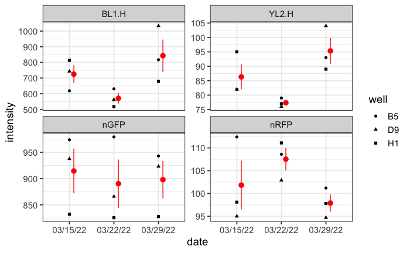

```r
dat %>% filter(host == "156") %>%
  pivot_longer(BL1.H:nRFP, names_to = "parameter", values_to = "intensity") %>%
  mutate(parameter = ordered(parameter, levels = c("BL1.H", "YL2.H", "nGFP", "nRFP"))) %>%
  ggplot(aes(x = date, y = intensity)) + geom_point(aes(shape = well)) +
  stat_summary(geom = "pointrange", color = "red", position = position_nudge(x = 0.1)) +
  facet_wrap(~parameter, scale = "free_y") +
  theme_bw(base_size = 14)
```

> 03/29/22 D9 showed higher background fluorescence than the others. after checking the gating result, I found that NA-156-2 sample in D9 had a slightly wider distribution, and the 2d cluster gate is also wider than the other two samples. The cell size normalized intensity doesn’t show the same pattern, suggesting that at least some of the difference could be due to cell size variation. Try just averaging the three blank wells and perform the background removal.

Subtract the background

```r
bg <- dat %>%
  filter(host == "156") %>%
  group_by(date) %>%
  summarize(across(FSC.H:nRFP, ~ round(mean(.x),1))) %>%
  column_to_rownames(var = "date")

dat1 <- dat %>%
  filter(host != "blank") %>%
  select(date:host, FSC.H:nRFP) %>%
  mutate(
    BL1.H = BL1.H - bg[date, "BL1.H"],
    YL2.H = YL2.H - bg[date, "YL2.H"],
    nGFP = nGFP - bg[date, "nGFP"],
    nRFP = nRFP - bg[date, "nRFP"],
  )
```

Double check that the subtraction worked correctly

```
No summary function supplied, defaulting to `mean_se()`
No summary function supplied, defaulting to `mean_se()`
No summary function supplied, defaulting to `mean_se()`
No summary function supplied, defaulting to `mean_se()`
```

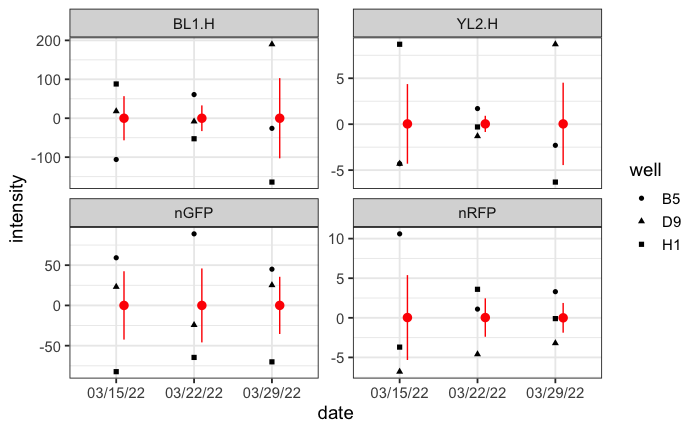

```r
dat1 %>% filter(host == "156") %>%
  pivot_longer(BL1.H:nRFP, names_to = "parameter", values_to = "intensity") %>%
  mutate(parameter = ordered(parameter, levels = c("BL1.H", "YL2.H", "nGFP", "nRFP"))) %>%
  ggplot(aes(x = date, y = intensity)) + geom_point(aes(shape = well)) +
  stat_summary(geom = "pointrange", color = "red", position = position_nudge(x = 0.1)) +
  facet_wrap(~parameter, scale = "free_y") +
  theme_bw(base_size = 14)
```

```r
# remove the yH156 samples
dat1 <- dat1 %>%
  filter(host != "156") %>%
  mutate(host = factor(host, levels = c("373", "555"), labels = c("pho2∆", "PHO2")))
```

## 3. Consistency across plates.

Check the background-subtracted fluorescence values for the host strains (yH373 and yH555) as well as the positive control strain (pH188 in yH373 or yH555 backgrounds), both of which are present on each plate.

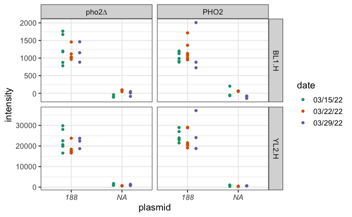

```r
dat1 %>% filter(plasmid %in% c("188", "NA")) %>%
  pivot_longer(BL1.H:YL2.H, names_to = "parameter", values_to = "intensity") %>%
  #mutate(parameter = ordered(parameter, levels = c("BL1.H", "YL2.H", "nGFP", "nRFP"))) %>%
  ggplot(aes(x = plasmid, y = intensity, color = date)) +
  geom_point(position = position_dodge(0.5)) +
  scale_color_brewer(type = "qual", palette = 2) +
  facet_grid(parameter~host, scale = "free_y") +
  theme_bw(base_size = 14) +
  theme(axis.text.x = element_text(face = 3))
```

> 1. The host strain fluorescence levels appear to be consistent across the three days. Additionally, their GFP levels are zero, as expected.
> 2. The positive control strain has strong BL1.H and correspondingly has strong YL2.H.

The size normalized values show slightly lower variance:

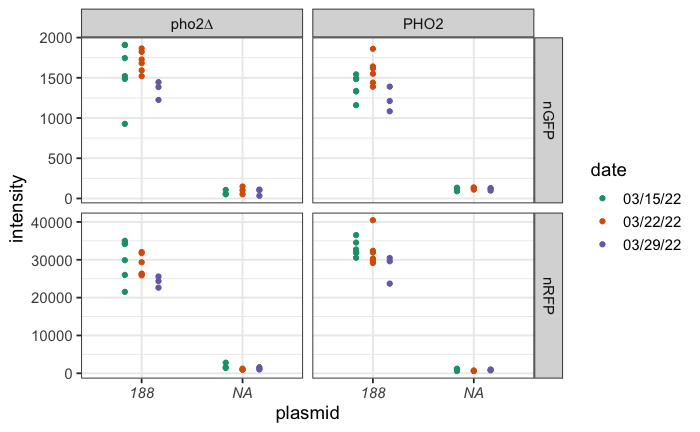

```r
dat1 %>% filter(plasmid %in% c("188", "NA")) %>%
  pivot_longer(nGFP:nRFP, names_to = "parameter", values_to = "intensity") %>%
  #mutate(parameter = ordered(parameter, levels = c("BL1.H", "YL2.H", "nGFP", "nRFP"))) %>%
  ggplot(aes(x = plasmid, y = intensity, color = date)) +
  geom_point(position = position_dodge(0.5)) +
  scale_color_brewer(type = "qual", palette = 2) +
  facet_grid(parameter~host, scale = "free_y") +
  theme_bw(base_size = 14) +
  theme(axis.text.x = element_text(face = 3))
```

## 4. Well position

*Rationale*

- In my original plate design, I placed a positive control strain (envisioned CgPho4-mNeon in *PHO2* background for example) in the control columns (1, 5, 9) on every other row (A, C, E, G). The reason for this is to use it to identify any well position effect on the fluorescence readings.
- In Emily’s implementation, she instead put **a pair** of strains, namely pH188-yH323 and pH188-yH555 in these wells. This means I cannot use the positive control wells exactly the way as I designed them. But I can still use them to spot any trend.

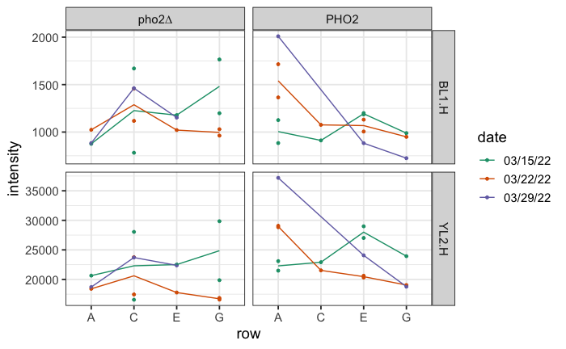

```r
dat1 %>%
  filter(plasmid == "188") %>%
  separate(well, into = c("row", "col"), sep = 1) %>%
  pivot_longer(BL1.H:YL2.H, names_to = "parameter", values_to = "intensity") %>%
  ggplot(aes(x = row, y = intensity, group = date)) +
  geom_point(aes(color = date), size = 1) +
  #geom_line(aes(color = date), size = 0.4) +
  stat_summary(aes(color = date), geom = "line", fun = mean) +
  scale_color_brewer(type = "qual", palette = 2) +
  facet_grid(parameter~host, scales = "free_y") +
  theme_bw(base_size = 14)
```

> - no obivous trend between the rows (or columns, not shown)
> - a clear correlation between YL2.H and BL1.H. at least part of this is due to the cell size differences – see size normalized data below:

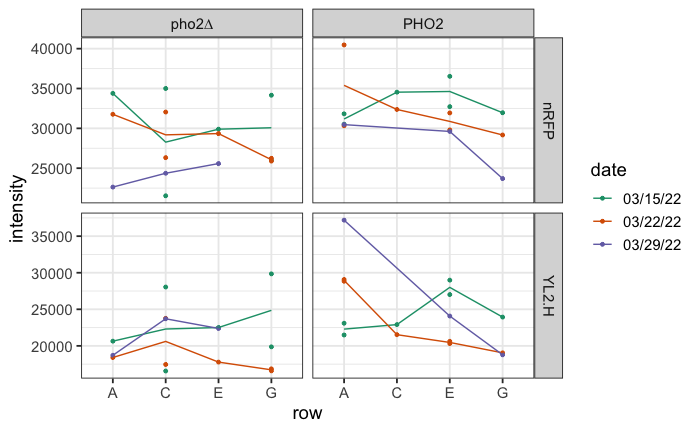

```r
dat1 %>%
  filter(plasmid == "188") %>%
  separate(well, into = c("row", "col"), sep = 1) %>%
  pivot_longer(c(YL2.H, nRFP), names_to = "parameter", values_to = "intensity") %>%
  ggplot(aes(x = row, y = intensity, group = date)) +
  geom_point(aes(color = date), size = 1) +
  #geom_line(aes(color = date), size = 0.4) +
  stat_summary(aes(color = date), geom = "line", fun = mean) +
  scale_color_brewer(type = "qual", palette = 2) +
  facet_grid(parameter~host, scales = "free_y") +
  theme_bw(base_size = 14)
```

- What we care about is the ratio between Pho4-mNeon and *PHO5pr*-mCherry

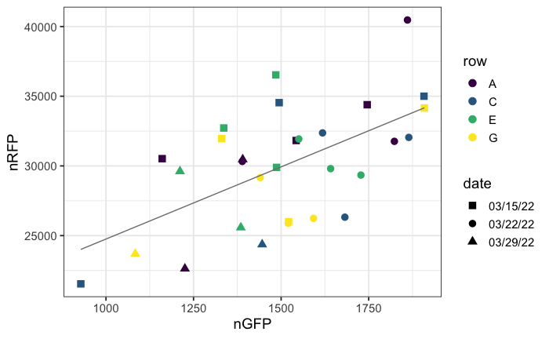

```r
dat1 %>%
  filter(plasmid == "188") %>%
  separate(well, into = c("row", "col"), sep = 1) %>%
  ggplot(aes(x = nGFP, y = nRFP)) +
  geom_point(aes(shape = date, color = row), size = 3) +
  stat_smooth(method = "lm", se = FALSE, color = "gray50", size = 0.5) +
  scale_color_viridis_d() +
  scale_shape_manual(values = 15:17) +
  #scale_x_log10() + scale_y_log10() +
  #facet_grid(parameter~host, scales = "free_y") +
  theme_bw(base_size = 14)
```

> - There is variation in BL1.H and correspondingly in YL2.H, but the ratio between the two are very consistent

Let’s check both ScPho4 (pH194) and CgPho4 (pH188) to see if their behaviors are consistent across the days.

```
No summary function supplied, defaulting to `mean_se()`
No summary function supplied, defaulting to `mean_se()`
No summary function supplied, defaulting to `mean_se()`
No summary function supplied, defaulting to `mean_se()`
No summary function supplied, defaulting to `mean_se()`
No summary function supplied, defaulting to `mean_se()`
```

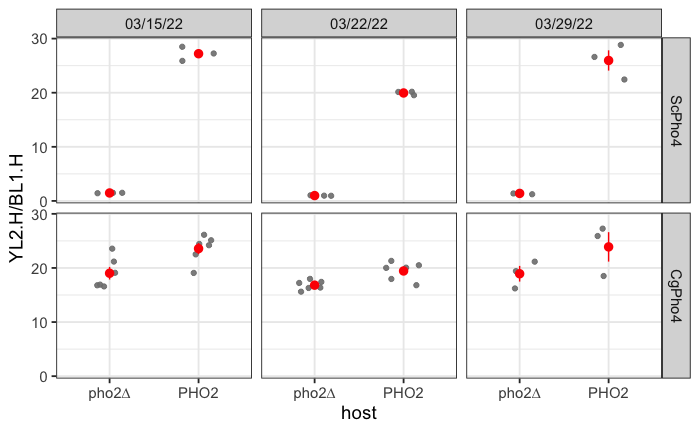

```r
dat1 %>%
  filter(plasmid %in% c("188", "194")) %>%
  mutate(`YL2.H/BL1.H` = YL2.H/BL1.H,
  #mutate(`YL2.H/BL1.H` = nRFP/nGFP,
         Pho4 = factor(plasmid, levels = c("194", "188"),
                       labels = c("ScPho4", "CgPho4"))) %>%
  separate(well, into = c("row", "col"), sep = 1) %>%
  ggplot(aes(x = host, y = `YL2.H/BL1.H`)) +
  geom_point(color = alpha("gray50", 0.9), position = position_jitter(0.2)) +
  stat_summary( geom = "pointrange", color = "red") +
  facet_grid(Pho4~date) +
  theme_bw(base_size = 14)
```

## 5. High variance samples

Summarize the background subtracted data by calculating the means and cv for each strain.

```r
dat2 <- dat1 %>%
  select(-nGFP, -nRFP) %>%
  pivot_longer(FSC.H:YL2.H, names_to = "parameter", values_to = "intensity") %>%
  group_by(date, plasmid, host, parameter) %>%
  summarize(
    n = n(),
    mean = round(mean(intensity)),
    cv = num(sd(intensity)/mean(intensity), digits = 2)
  ) %>%
  arrange(desc(cv))
```

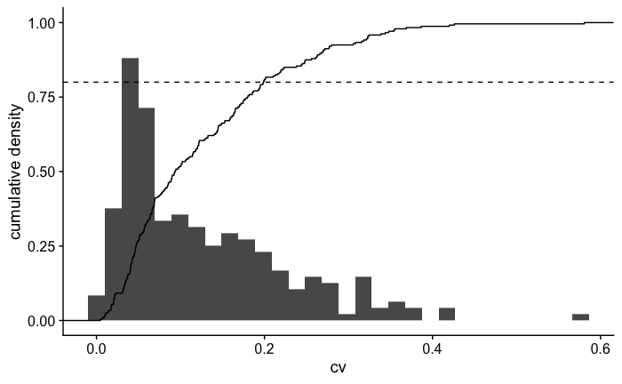

```r
dat2 %>% filter(plasmid != "NA") %>%
  ggplot(aes(x = cv)) + geom_histogram(aes(y = ..density../10)) + stat_ecdf() +
  geom_hline(yintercept = 0.8, linetype = 2) +
  ylab("cumulative density") + theme_cowplot()
```

> 80% of the samples have a CV < 20%. Label the remaining samples as high var

| date | plasmid | host | parameter | n | mean | cv |
| --- | --- | --- | --- | --- | --- | --- |
| 03/15/22 | NA | PHO2 | BL1.H | 3 | 27 | 5.54 |
| 03/29/22 | 188 | PHO2 | BL1.H | 3 | 1206 | 0.58 |
| 03/15/22 | NA | PHO2 | YL2.H | 3 | 709 | 0.46 |
| 03/22/22 | 232 | pho2∆ | BL1.H | 3 | 1310 | 0.43 |
| 03/29/22 | 224 | PHO2 | YL2.H | 3 | 1323 | 0.42 |
| 03/15/22 | NA | pho2∆ | YL2.H | 3 | 1213 | 0.39 |
| 03/15/22 | 231 | pho2∆ | YL2.H | 3 | 11008 | 0.39 |
| 03/15/22 | 231 | pho2∆ | BL1.H | 3 | 3886 | 0.37 |
| 03/29/22 | 188 | PHO2 | YL2.H | 3 | 26681 | 0.36 |
| 03/15/22 | 229 | pho2∆ | BL1.H | 3 | 1289 | 0.35 |

[output cut: 41 more lines]